# TP3 : Visualisation des donnees spatiales

> Charger les librairies `leaflet`, `sf`, `mapsf` et `dplyr`

```r
library(leaflet) # Cartographie interactive
library(sf) # Gestion de donnees spatiales + geotraitement
library(mapsf) # Cartographie
library(dplyr) # Gestion de donnees
```

## Question 1

- Charger les donnees spatiales du decoupage administratif de l’ile de france au niveau `communal` et `departemental` et les stocker dans `if_com_geom` et `if_dep_geom`.
- Charger les resultats du recensement de la population de l’ile de france aux niveaux `communal` et `departemental` et les stocker dans `pop_if_com` et `pop_if_dep`.

```r
# Chargement des donnees spatiales du decoupage administratif de l'ile de france au niveau `communal` et `departemental` et les stocker dans  `if_com_geom` et `if_dep_geom`.
if_com_geom = st_read("data/dataset_tp3/if_com_geom.shp")
if_dep_geom = st_read("data/dataset_tp3/if_dep_geom.shp")
pop_if_com = read.csv("data/dataset_tp3/pop_if_com.csv")
pop_if_dep = read.csv("data/dataset_tp3/pop_if_dep.csv")
```

## Question 2

- Utiliser la fonction `as.character` pour transformer `pop_if_dep$INSEE_DEP` et `pop_if_com$INSEE_COM` en type `character`.
- Utiliser la fonction `inner_join` pour fusionner le decoupage et les resultats du recensement de la population en ile de france au niveau `departemental` et stocker le resultat dans `pop_if_dep_geom`.
- Utiliser la fonction `inner_join` pour fusionner le decoupage et les resultats du recensement de la population en ile de france au niveau `communal` et stocker le resultat dans `pop_if_com_geom`.

```r
pop_if_dep$INSEE_DEP <- as.character(pop_if_dep$INSEE_DEP)
pop_if_com$INSEE_COM <- as.character(pop_if_com$INSEE_COM)

pop_if_dep_geom <- inner_join(if_dep_geom, pop_if_dep, by = c("INSEE_DEP" = "INSEE_DEP"))
pop_if_com_geom <- inner_join(if_com_geom, pop_if_com, by = c("INSEE_COM" = "INSEE_COM"))
```

## Question 3

- Utiliser la fonction `mf_map` de type `choro` et `border = NA` pour visualiser la population de l’ile de france par commune.
- Utiliser la fonction `mf_map` de type `base` et `border = "white"` pour visualiser et ajouter les contours des departements sur le meme graphique.

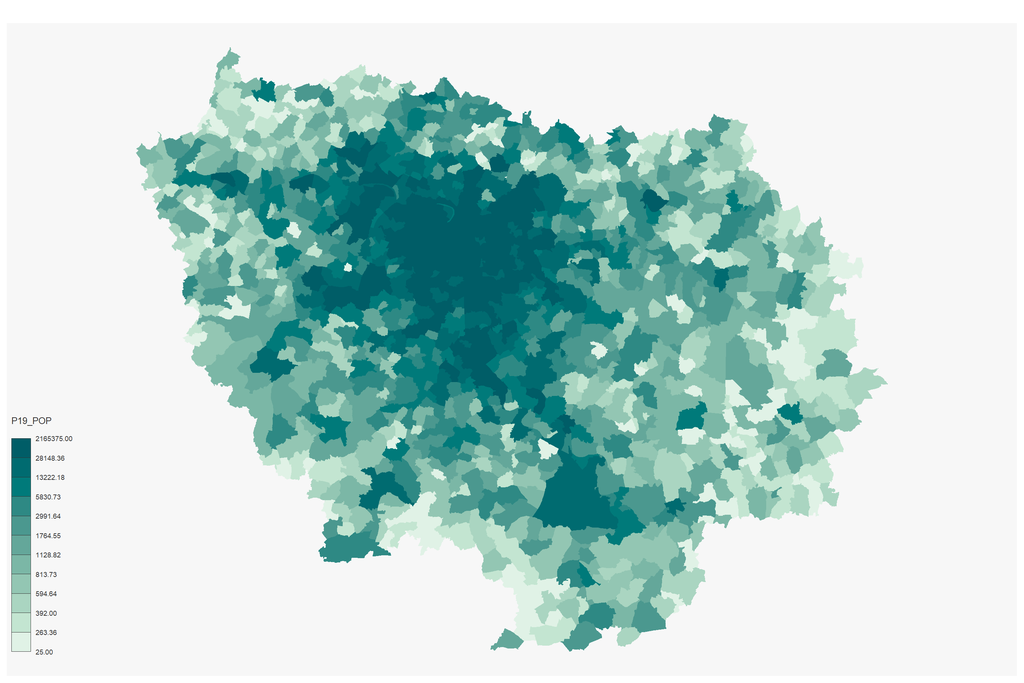

```r
mf_map(pop_if_com_geom, type = "choro", var = "P19_POP", border = NA)
```

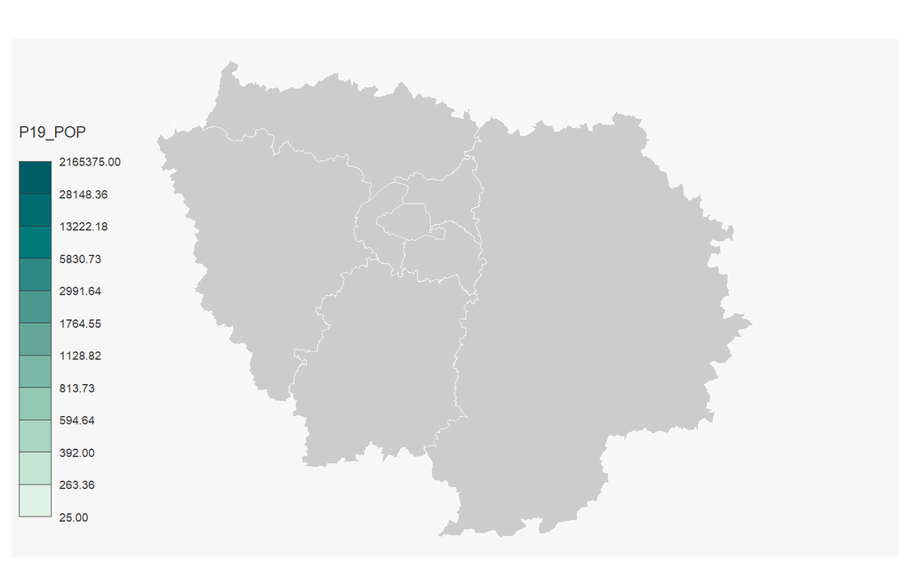

```r
mf_map(pop_if_com_geom, type = "choro", var = "P19_POP", border = NA)
mf_map(pop_if_dep_geom, type = "base",  border = "white", add = TRUE)
```

> Decommenter et utiliser les codes suivants pour creer une nouvelle colonne `P19_MAX_TRANCHE` qui contient la tranche d’age dominante en ile de france aux niveaux `communal` et `departemental`.

```r
maxcol <- max.col(pop_if_dep_geom[7:11] %>% as_tibble()%>% dplyr::select(-geometry), ties.method = "first")+6
pop_if_dep_geom <-  pop_if_dep_geom%>%mutate(P19_MAX_TRANCHE = colnames(pop_if_dep_geom)[maxcol])
```

```r
maxcol <- max.col(pop_if_com_geom[15:19] %>% as_tibble()%>% dplyr::select(-geometry), ties.method = "first")+14
pop_if_com_geom <-  pop_if_com_geom%>%mutate(P19_MAX_TRANCHE = colnames(pop_if_com_geom)[maxcol])
```

## Question 4

- Utiliser la fonction `mf_map` de type `typo` et `border = "white"` pour visualiser la tranche d’age dominante par departement.
- Utiliser la fonction `mf_label` pour afficher et ajouter les noms des departements sur la meme visualisation.
- Utiliser la fonction `mf_layout` pour ajouter un titre, un auteur (vous) et une source (INSEE & IGN, 2022) a votre visualisation

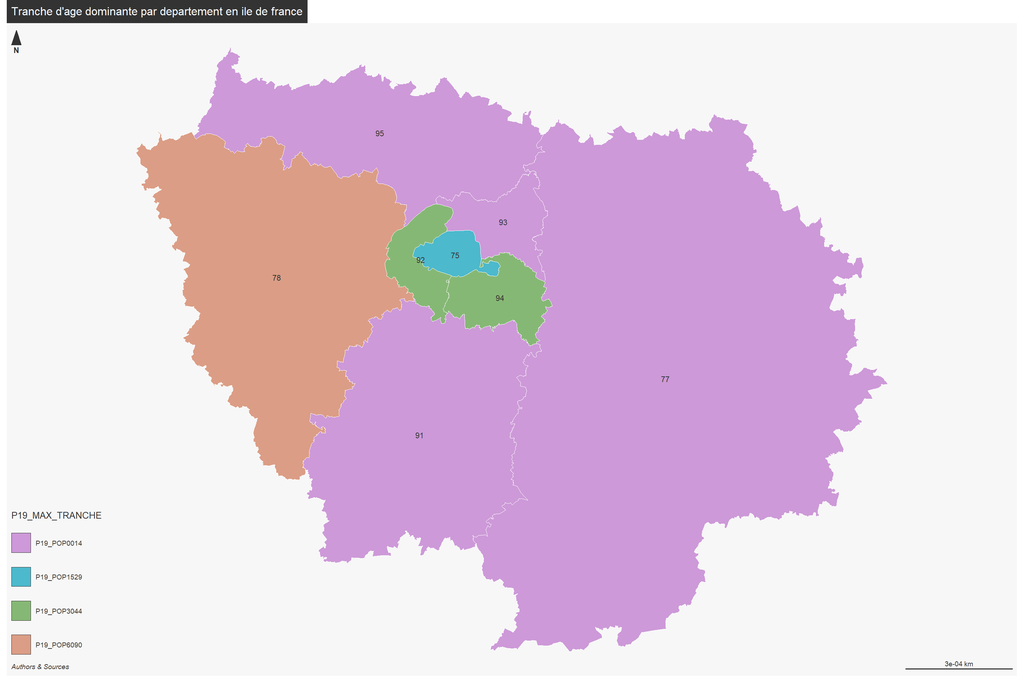

```r
mf_map(pop_if_dep_geom, type = "typo", var = "P19_MAX_TRANCHE", border = "white")
mf_label(pop_if_dep_geom, var = "INSEE_DEP", add = TRUE)
mf_layout(title = "Tranche d'age dominante par departement en ile de france")
```

## Question 5

```r
#domain_range <- range(pop_if_dep_geom$P19_MAX_TRANCHE)
#leaflet(pop_if_dep_geom) %>%
#  addPolygons(fillColor = ~colorNumeric(palette = "Set1", domain = domain_range)(P19_MAX_TRANCHE),
#              color = "black", weight = 1, opacity = 1, fillOpacity = 0.7, smoothFactor = 1) %>%
#  addProviderTiles(providers$CartoDB.Positron) %>%
#  addLegend("bottomright",
#            pal = colorNumeric(palette = "Set1", domain = domain_range),
#            values = ~P19_MAX_TRANCHE,
#            title = "Tranche d'age dominante",
#            opacity = 1)
```

## Question 6

- Utiliser la fonction `mf_map` de type `typo` et `border = "white"` pour visualiser la tranche d’age dominante par commune. * Utiliser la fonction `mf_map` de type `base` et `border = "black"` pour visualiser et ajouter les contours des departements sur la meme visualisation.
- Utiliser la fonction `mf_layout` pour ajouter un titre, un auteur (vous) et une source (INSEE & IGN, 2022) a votre visualisation

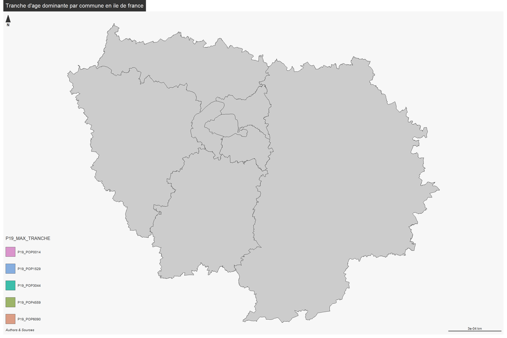

```r
mf_map(pop_if_com_geom, type = "typo", var = "P19_MAX_TRANCHE", border = "white")
mf_map(pop_if_dep_geom, type = "base",  border = "black", add = TRUE)
mf_layout(title = "Tranche d'age dominante par commune en ile de france")
```

## Question 7

```r
#domain_range <- range(pop_if_com_geom$P19_MAX_TRANCHE)
#leaflet(pop_if_com_geom) %>%
#  addPolygons(fillColor = ~colorNumeric(palette = "Set1", domain = domain_range)(P19_MAX_TRANCHE),
#              color = "black", weight = 1, opacity = 1, fillOpacity = 0.7, smoothFactor = 1) %>%
#  addProviderTiles(providers$CartoDB.Positron) %>%
#  addLegend("bottomright",
#            pal = colorNumeric(palette = "Set1", domain = domain_range),
#            values = ~P19_MAX_TRANCHE,
#            title = "Tranche d'age dominante",
#            opacity = 1)
```

> Decommenter et utiliser les codes suivants pour creer une nouvelle colonne `P19_NB_MAX_TRANCHE` qui contient le nombre de personnes de la tranche d’age dominante par commune.

```r
pop_if_com_geom_mp <- pop_if_com_geom %>%
                      rowwise %>%
                      mutate(P19_NB_MAX_TRANCHE = cur_data()[[P19_MAX_TRANCHE]]) %>%
                      ungroup
```

## Question 8

```r
#mf_map(pop_if_com_geom_mp, type = "prop_typo", var = "P19_MAX_TRANCHE", prop = "P19_NB_MAX_TRANCHE", border = "white")
#mf_map(pop_if_com_geom, type = "base",  border = "white", add = TRUE)
#mf_map(pop_if_dep_geom, type = "base",  border = "black", add = TRUE)
#mf_layout(title = "Tranche d'age dominante et son nombre de personnes par commune en ile de france")
```